# Presentation on Propser Loan Dataset Data Analysis

## by Aisha Awudu

## Investigation Overview

> The objective of the project is to use Python visualization libraries to explore a dataset thoroughly. The analysis begins with exploring univariate variables followed by bivariate and multivariate analysis. Variables are divided into two categories:
> 1. The demorgraphic information (The basic borrower information)
> 2. The loan performance indicators (Loan performance variables)

## Dataset Overview

> Data is from Prosper Loan database. The dataset has are 113,937 loans entries with 81 variables. The variables are numeric and categorical in nature where 61 variables are of numeric type and the remaing of string or object type.

## What is the current state of loans, are there more default loans?

> From the total number of loans, 56,576 being the highest represents current loans, whereas, 38,074 of the loans have been completed. There is a record of 5,018 defaulted loans.

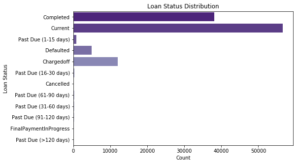

## What is the relationship between the Borrower Rate on loans and employment status?

> Employed borrowers have a highest rate range between 30-35% .Retired borrowers have a highest borrower rate of 35%

[figure not shown]

## What is the relationship between EmploymentStatus vs BorrowerRate in each LoanStatus?

> Retired and not employed have the highest borrower rate especially with past due loans.

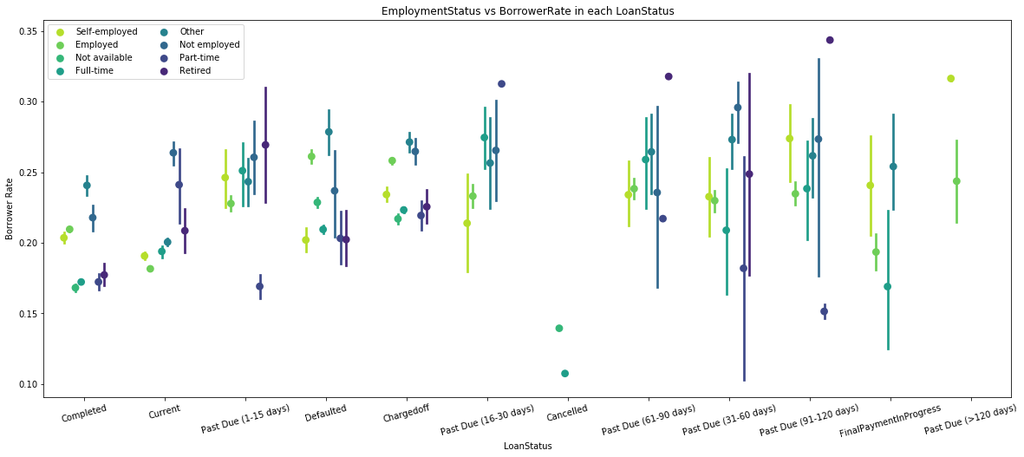

### Insights

We can conclude loans are normally of very high risk, even though the default rates seemed comparatively low considering completed, current and cancelled loans. Prosper loans seems to have kept in measures to reduce default rates, but more needs to be to improve risks.